# Decision Tree Lab

Zoe Pham

November 10, 2021

# Problem Statement

Congrats! You just graduated UVA’s MSDS program and got a job working at the Treasury Department. In partnership with Congress members the Treasury has been ask to come up with innovative ways to create tax policy.

*In doing so they want to be able to reliably predict whether American workers make more than $50,000 a year and also which variables seem to be most contributing to predicting this outcome.*

You would like to be able to explain the model to the mere mortals around you but need a fairly robust and flexible approach so you’ve chosen to use decision trees to get started and will possibly move to a ensemble model if needed.

In doing so, similar to great data scientists of the past you remembered the excellent education provided to you at UVA in a undergrad data science course and have outline 20ish steps that will need to be undertaken to complete this task (you can add more or combine if needed). As always, you will need to make sure to #comment your work heavily.

# Preparing Data

```
## spec_tbl_df [32,561 x 15] (S3: spec_tbl_df/tbl_df/tbl/data.frame)
##  $ age           : num [1:32561] 39 50 38 53 28 37 49 52 31 42 ...
##  $ workclass     : chr [1:32561] "State-gov" "Self-emp-not-inc" "Private" "Private" ...
##  $ fnlwgt        : num [1:32561] 77516 83311 215646 234721 338409 ...
##  $ education     : chr [1:32561] "Bachelors" "Bachelors" "HS-grad" "11th" ...
##  $ education-num : num [1:32561] 13 13 9 7 13 14 5 9 14 13 ...
##  $ marital-status: chr [1:32561] "Never-married" "Married-civ-spouse" "Divorced" "Married-civ-spouse" ...
##  $ occupation    : chr [1:32561] "Adm-clerical" "Exec-managerial" "Handlers-cleaners" "Handlers-cleaners" ...
##  $ relationship  : chr [1:32561] "Not-in-family" "Husband" "Not-in-family" "Husband" ...
##  $ race          : chr [1:32561] "White" "White" "White" "Black" ...
##  $ sex           : chr [1:32561] "Male" "Male" "Male" "Male" ...
##  $ capital-gain  : num [1:32561] 2174 0 0 0 0 ...
##  $ capital-loss  : num [1:32561] 0 0 0 0 0 0 0 0 0 0 ...
##  $ hours-per-week: num [1:32561] 40 13 40 40 40 40 16 45 50 40 ...
##  $ native-country: chr [1:32561] "United-States" "United-States" "United-States" "United-States" ...
##  $ salary        : chr [1:32561] "0" "0" "0" "0" ...
##  - attr(*, "spec")=
##   .. cols(
##   ..   age = col_double(),
##   ..   workclass = col_character(),
##   ..   fnlwgt = col_double(),
##   ..   education = col_character(),
##   ..   `education-num` = col_double(),
##   ..   `marital-status` = col_character(),
##   ..   occupation = col_character(),
##   ..   relationship = col_character(),
##   ..   race = col_character(),
##   ..   sex = col_character(),
##   ..   `capital-gain` = col_double(),
##   ..   `capital-loss` = col_double(),
##   ..   `hours-per-week` = col_double(),
##   ..   `native-country` = col_character(),
##   ..   salary = col_character()
##   .. )
##  - attr(*, "problems")=<externalptr>
```

```
## spec_tbl_df [32,561 x 15] (S3: spec_tbl_df/tbl_df/tbl/data.frame)
##  $ age           : num [1:32561] 39 50 38 53 28 37 49 52 31 42 ...
##  $ workclass     : Factor w/ 9 levels "?","Federal-gov",..: 8 7 5 5 5 5 5 7 5 5 ...
##  $ fnlwgt        : num [1:32561] 77516 83311 215646 234721 338409 ...
##  $ education     : Factor w/ 16 levels "10th","11th",..: 10 10 12 2 10 13 7 12 13 10 ...
##  $ education-num : num [1:32561] 13 13 9 7 13 14 5 9 14 13 ...
##  $ marital-status: Factor w/ 7 levels "Divorced","Married-AF-spouse",..: 5 3 1 3 3 3 4 3 5 3 ...
##  $ occupation    : Factor w/ 15 levels "?","Adm-clerical",..: 2 5 7 7 11 5 9 5 11 5 ...
##  $ relationship  : Factor w/ 6 levels "Husband","Not-in-family",..: 2 1 2 1 6 6 2 1 2 1 ...
##  $ race          : Factor w/ 5 levels "Amer-Indian-Eskimo",..: 5 5 5 3 3 5 3 5 5 5 ...
##  $ sex           : Factor w/ 2 levels "Female","Male": 2 2 2 2 1 1 1 2 1 2 ...
##  $ capital-gain  : num [1:32561] 2174 0 0 0 0 ...
##  $ capital-loss  : num [1:32561] 0 0 0 0 0 0 0 0 0 0 ...
##  $ hours-per-week: num [1:32561] 40 13 40 40 40 40 16 45 50 40 ...
##  $ native-country: Factor w/ 42 levels "?","Cambodia",..: 40 40 40 40 6 40 24 40 40 40 ...
##  $ salary        : Factor w/ 2 levels "0","1": 1 1 1 1 1 1 1 2 2 2 ...
##  - attr(*, "spec")=
##   .. cols(
##   ..   age = col_double(),
##   ..   workclass = col_character(),
##   ..   fnlwgt = col_double(),
##   ..   education = col_character(),
##   ..   `education-num` = col_double(),
##   ..   `marital-status` = col_character(),
##   ..   occupation = col_character(),
##   ..   relationship = col_character(),
##   ..   race = col_character(),
##   ..   sex = col_character(),
##   ..   `capital-gain` = col_double(),
##   ..   `capital-loss` = col_double(),
##   ..   `hours-per-week` = col_double(),
##   ..   `native-country` = col_character(),
##   ..   salary = col_character()
##   .. )
##  - attr(*, "problems")=<externalptr>
```

```
##
##         10th         11th         12th      1st-4th      5th-6th      7th-8th
##          933         1175          433          168          333          646
##          9th   Assoc-acdm    Assoc-voc    Bachelors    Doctorate      HS-grad
##          514         1067         1382         5355          413        10501
##      Masters    Preschool  Prof-school Some-college
##         1723           51          576         7291
```

```
##
##           other    Craft-repair Exec-managerial  Prof-specialty
##           20256            4099            4066            4140
```

## Determining Prevalence

```
##
##     0     1
## 24720  7841
```

```
## [1] 0.7591904
```

## Splitting Data: Test, Tune, Train Set

```
## [1] 22793    14
```

```
## [1] 4884   14
```

```
## [1] 4884   14
```

# Building the Model

```
## tibble [22,793 x 13] (S3: tbl_df/tbl/data.frame)
##  $ age           : num [1:22793] 39 50 38 53 49 52 31 42 37 30 ...
##  $ workclass     : Factor w/ 4 levels "other","Private",..: 1 4 2 2 2 4 2 2 2 1 ...
##  $ education     : Factor w/ 6 levels "No_HS","other",..: 3 3 4 1 1 4 5 3 6 3 ...
##  $ education-num : num [1:22793] 13 13 9 7 5 9 14 13 10 13 ...
##  $ marital-status: Factor w/ 2 levels "not_married",..: 1 2 1 2 2 2 1 2 2 2 ...
##  $ occupation    : Factor w/ 4 levels "other","Craft-repair",..: 1 3 1 1 1 3 4 3 3 4 ...
##  $ relationship  : Factor w/ 6 levels "Husband","Not-in-family",..: 2 1 2 1 2 1 2 1 1 1 ...
##  $ race          : Factor w/ 5 levels "Amer-Indian-Eskimo",..: 5 5 5 3 3 5 5 5 3 2 ...
##  $ sex           : Factor w/ 2 levels "Female","Male": 2 2 2 2 1 2 1 2 2 2 ...
##  $ capital-gain  : num [1:22793] 2174 0 0 0 0 ...
##  $ capital-loss  : num [1:22793] 0 0 0 0 0 0 0 0 0 0 ...
##  $ hours-per-week: num [1:22793] 40 13 40 40 16 45 50 40 80 40 ...
##  $ native-country: Factor w/ 2 levels "other","US": 2 2 2 2 1 2 2 2 2 1 ...
```

```
##  Factor w/ 2 levels "0","1": 1 1 1 1 1 2 2 2 2 2 ...
```

```
## C5.0
##
## 22793 samples
##    13 predictor
##     2 classes: '0', '1'
##
## No pre-processing
## Resampling: Cross-Validated (5 fold, repeated 5 times)
## Summary of sample sizes: 18235, 18235, 18234, 18234, 18234, 18234, ...
## Resampling results across tuning parameters:
##
##   winnow  trials  Accuracy   Kappa
##   FALSE    1      0.8644147  0.6009400
##   FALSE    5      0.8592377  0.5942514
##   FALSE   10      0.8630458  0.6001763
##   FALSE   15      0.8638092  0.6043082
##   FALSE   20      0.8644674  0.6016621
##    TRUE    1      0.8629932  0.5953122
##    TRUE    5      0.8579126  0.5840217
##    TRUE   10      0.8621771  0.5912756
##    TRUE   15      0.8623350  0.5985907
##    TRUE   20      0.8622297  0.5919409
##
## Tuning parameter 'model' was held constant at a value of tree
## Accuracy was used to select the optimal model using the largest value.
## The final values used for the model were trials = 20, model = tree and winnow
##  = FALSE.
```

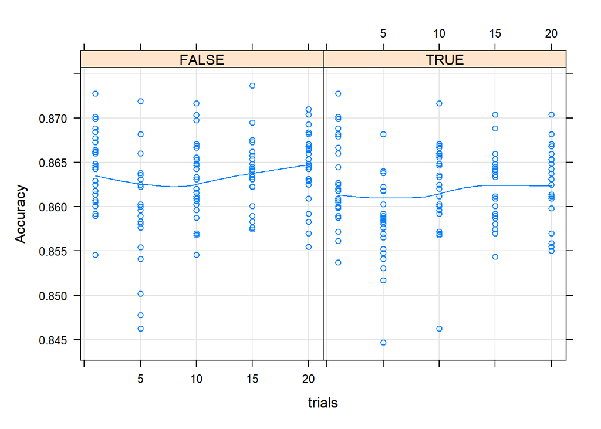

```
## C5.0 variable importance
##
##                Overall
## marital-status  100.00
## age             100.00
## capital-gain    100.00
## relationship     94.67
## education-num    92.96
## capital-loss     92.89
## occupation       91.04
## hours-per-week   63.95
## race             33.71
## workclass        31.23
## education        17.87
## native-country   10.04
## sex               0.00
```

After running the decision tree, the most important variables include marital status, age, and capital gain. These three variables are probably most important in predicting whether American workers make more than $50,000 a year because married couples tend to have higher total incomes from double incomes per spouse which single people lack, younger people may earn less as they are in lower paying entry jobs as opposed to older people, and capital gain affects how much a person’s existing wealth grows. ## Data Plot

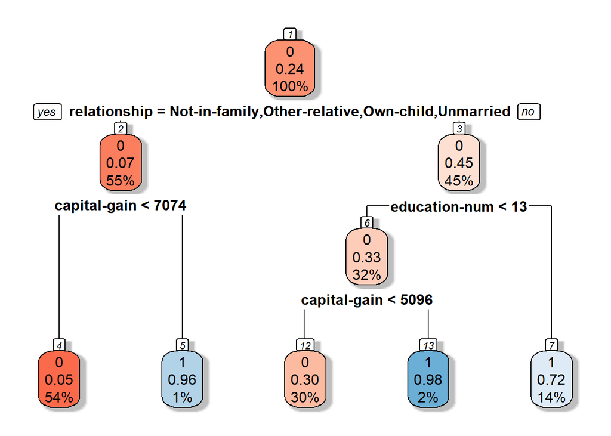

# Interpreting Results ## Target Variable Estimation

### Actual vs. Predicted Values

```
##
## xx_pred_tune    0    1
##            0 3472  459
##            1  236  717
```

## Confusion Matrix

```
## Confusion Matrix and Statistics
##
##           Actual
## Prediction    0    1
##          0 3472  459
##          1  236  717
##
##                Accuracy : 0.8577
##                  95% CI : (0.8476, 0.8674)
##     No Information Rate : 0.7592
##     P-Value [Acc > NIR] : < 2.2e-16
##
##                   Kappa : 0.5838
##
##  Mcnemar's Test P-Value : < 2.2e-16
##
##             Sensitivity : 0.9364
##             Specificity : 0.6097
##          Pos Pred Value : 0.8832
##          Neg Pred Value : 0.7524
##              Prevalence : 0.7592
##          Detection Rate : 0.7109
##    Detection Prevalence : 0.8049
##       Balanced Accuracy : 0.7730
##
##        'Positive' Class : 0
##
```

The validation set correctly predicted which Americans made over $50,000 a year with 85% accuracy, which is pretty good. The model’s sensitivity is 93% and the specificity is 61%, showing a pretty good true positive rate but an okay false positive rate (100%-61%=39%).

After checking the confusion matrix, the metric that might be best to analyze our model predicting whether Americans make more than $50,000 a year is sensitivity because determining which salaries match our criteria is vital in constructing a tax policy around it. ## ROC and AUC

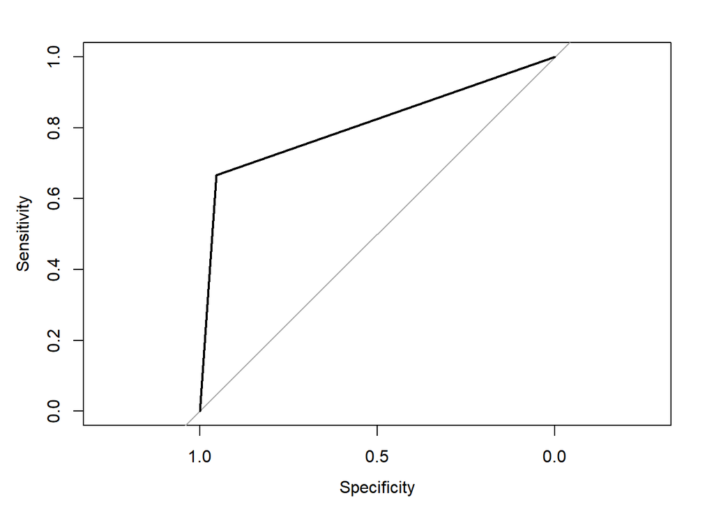

```
## Confusion Matrix and Statistics
##
##           Actual
## Prediction    0    1
##          0 3666  763
##          1   42  413
##
##                Accuracy : 0.8352
##                  95% CI : (0.8245, 0.8455)
##     No Information Rate : 0.7592
##     P-Value [Acc > NIR] : < 2.2e-16
##
##                   Kappa : 0.4298
##
##  Mcnemar's Test P-Value : < 2.2e-16
##
##             Sensitivity : 0.35119
##             Specificity : 0.98867
##          Pos Pred Value : 0.90769
##          Neg Pred Value : 0.82773
##               Precision : 0.90769
##                  Recall : 0.35119
##                      F1 : 0.50644
##              Prevalence : 0.24079
##          Detection Rate : 0.08456
##    Detection Prevalence : 0.09316
##       Balanced Accuracy : 0.66993
##
##        'Positive' Class : 1
##
```

```
## Confusion Matrix and Statistics
##
##           Actual
## Prediction    0    1
##          0 3386  325
##          1  322  851
##
##                Accuracy : 0.8675
##                  95% CI : (0.8577, 0.8769)
##     No Information Rate : 0.7592
##     P-Value [Acc > NIR] : <2e-16
##
##                   Kappa : 0.6374
##
##  Mcnemar's Test P-Value : 0.9373
##
##             Sensitivity : 0.7236
##             Specificity : 0.9132
##          Pos Pred Value : 0.7255
##          Neg Pred Value : 0.9124
##               Precision : 0.7255
##                  Recall : 0.7236
##                      F1 : 0.7246
##              Prevalence : 0.2408
##          Detection Rate : 0.1742
##    Detection Prevalence : 0.2402
##       Balanced Accuracy : 0.8184
##
##        'Positive' Class : 1
##
```

```
## Confusion Matrix and Statistics
##
##           Actual
## Prediction    0    1
##          0 3579  533
##          1  129  643
##
##                Accuracy : 0.8645
##                  95% CI : (0.8545, 0.8739)
##     No Information Rate : 0.7592
##     P-Value [Acc > NIR] : < 2.2e-16
##
##                   Kappa : 0.58
##
##  Mcnemar's Test P-Value : < 2.2e-16
##
##             Sensitivity : 0.5468
##             Specificity : 0.9652
##          Pos Pred Value : 0.8329
##          Neg Pred Value : 0.8704
##               Precision : 0.8329
##                  Recall : 0.5468
##                      F1 : 0.6602
##              Prevalence : 0.2408
##          Detection Rate : 0.1317
##    Detection Prevalence : 0.1581
##       Balanced Accuracy : 0.7560
##
##        'Positive' Class : 1
##
```

```
## Confusion Matrix and Statistics
##
##           Actual
## Prediction    0    1
##          0 2496   62
##          1 1212 1114
##
##                Accuracy : 0.7391
##                  95% CI : (0.7266, 0.7514)
##     No Information Rate : 0.7592
##     P-Value [Acc > NIR] : 0.9995
##
##                   Kappa : 0.4651
##
##  Mcnemar's Test P-Value : <2e-16
##
##             Sensitivity : 0.9473
##             Specificity : 0.6731
##          Pos Pred Value : 0.4789
##          Neg Pred Value : 0.9758
##               Precision : 0.4789
##                  Recall : 0.9473
##                      F1 : 0.6362
##              Prevalence : 0.2408
##          Detection Rate : 0.2281
##    Detection Prevalence : 0.4762
##       Balanced Accuracy : 0.8102
##
##        'Positive' Class : 1
##
```

```
## C5.0
##
## 22793 samples
##    13 predictor
##     2 classes: '0', '1'
##
## No pre-processing
## Resampling: Cross-Validated (5 fold, repeated 8 times)
## Summary of sample sizes: 18235, 18235, 18234, 18234, 18234, 18234, ...
## Resampling results across tuning parameters:
##
##   winnow  trials  Accuracy   Kappa
##   FALSE    1      0.8646625  0.6017255
##   FALSE    5      0.8593757  0.5949736
##   FALSE   10      0.8628746  0.5999443
##   FALSE   15      0.8637576  0.6039366
##   FALSE   20      0.8647118  0.6021875
##    TRUE    1      0.8630611  0.5944861
##    TRUE    5      0.8582294  0.5854771
##    TRUE   10      0.8617997  0.5888017
##    TRUE   15      0.8622548  0.5970512
##    TRUE   20      0.8626552  0.5920100
##
## Tuning parameter 'model' was held constant at a value of tree
## Accuracy was used to select the optimal model using the largest value.
## The final values used for the model were trials = 20, model = tree and winnow
##  = FALSE.
```

# Final Output

```
## Confusion Matrix and Statistics
##
##           Actual
## Prediction    0    1
##          0 3497  434
##          1  211  742
##
##                Accuracy : 0.8679
##                  95% CI : (0.8581, 0.8773)
##     No Information Rate : 0.7592
##     P-Value [Acc > NIR] : < 2.2e-16
##
##                   Kappa : 0.6138
##
##  Mcnemar's Test P-Value : < 2.2e-16
##
##             Sensitivity : 0.9431
##             Specificity : 0.6310
##          Pos Pred Value : 0.8896
##          Neg Pred Value : 0.7786
##              Prevalence : 0.7592
##          Detection Rate : 0.7160
##    Detection Prevalence : 0.8049
##       Balanced Accuracy : 0.7870
##
##        'Positive' Class : 0
##
```

## Summary

I learned that decision trees are powerful tools to build, train, tune, test, and evaluate machine learning predictive models that can be done with few computational resources and time. I found that tuning had a lot of trial and error in adjusting thresholds and adjusting hyperparameters, taking up a lot of time when not automated. ### Recommendations Some recommendations on how this decision tree model could be used moving forward could be to predict the amount of Americans with salaries over $50,000 to predict how much tax revenue would be made and how much tax percentage to levy to break even on government expenses; however, this prediction should only be used along with actual data gathering, such as surveying households across areas and limiting data sampling bias (gathering data in a variety of neighborhoods, with people of varying marital status, age, and race, etc.) so all Americans are represented.

### Questions

The hardest part of this process was deciding on hyperparameters to adjust, as tuning is very specific to my data’s behavior and structure, so I had to guess and check to see which hyperparameters worked best to improve my model.